# Analyse descriptive

## Description de la population

Le jeu de données est constitué de 569 entrées. Chacune de ces entrées correspond à une personne atteinte d’un cancer du sein chez qui une biopsie de la tumeur a été effectuée. Les noyaux des cellules tumorales on ensuite été énalysé et les données recueillies sont présentées dans le tableau ci-dessous. Pour chaque variable, on a **la moyenne** (mean), **l’erreur standard** (SE) et **la “pire”" valeur** (worst, c’est-à-dire la moyenne des trois plus grandes valeurs de la variable).

[interactive table not shown]

Les 10 variables mesurées sur les noyaux des cellules sont :

1. **Radius** : le rayon du noyau, qui est la moyenne des distances entre le centre du noyau et des points sur le périmètre
2. **Texture** : ecart-ype des valeurs des echelles de gris
3. **Perimeter** : le périmètre du noyau
4. **Area** : l’aire du noyau
5. **Smoothness** : la variation locale des longueurs du rayon
6. **Compactness**, compacité : perimeter^2 / area - 1
7. **Concavity**, concavité : sévérité des portions concaves du contour
8. **Concave points** : nombre de portions concaves du contour
9. **Symmetry** : la symétrie du noyau
10. **Fractal dimension** : “coastline approximation” - 1

Chaque échantillon a un identifiant et un diagnostic associé à la tumeur (maligne, M ; ou bénin, B). Il y a 357 tumeurs bénines (62.74 %) et 212 (37.26 %) tumeurs malignes.

Le tableau suivant résume quelques paramètres statistiques pour chaque variables :

|  | N | %/Mean | sd | Minimum | Med | Maximum | IQR |
| --- | --- | --- | --- | --- | --- | --- | --- |
| diagnosis | 569 |  |  |  |  |  |  |
| &nbsp;&nbsp;&nbsp;&nbsp;B | 357 | 63 |  |  |  |  |  |
| &nbsp;&nbsp;&nbsp;&nbsp;M | 212 | 37 |  |  |  |  |  |
| radius_mean | 569 |  |  | 7 | 13 | 28 | 4.1 |
| texture_mean | 569 |  |  | 9.7 | 19 | 39 | 5.6 |
| perimeter_mean | 569 |  |  | 44 | 86 | 188 | 29 |
| area_mean | 569 |  |  | 144 | 551 | 2501 | 362 |
| smoothness_mean | 569 |  |  | 0.053 | 0.096 | 0.16 | 0.019 |
| compactness_mean | 569 |  |  | 0.019 | 0.093 | 0.35 | 0.065 |
| concavity_mean | 569 |  |  | 0 | 0.062 | 0.43 | 0.1 |

[output cut: 23 more lines]

La densité de répartition des valeurs de chaque variables est raportée dans les graphiques suivants.

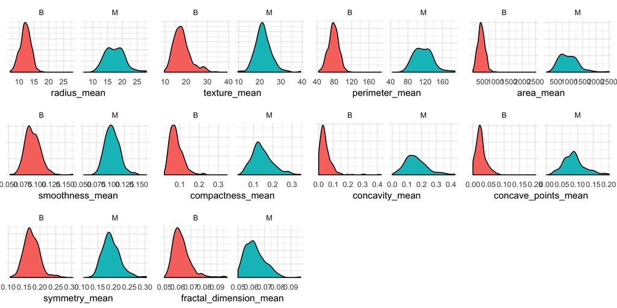

Graphique 1 : répartition des moyennes pour chaque variable

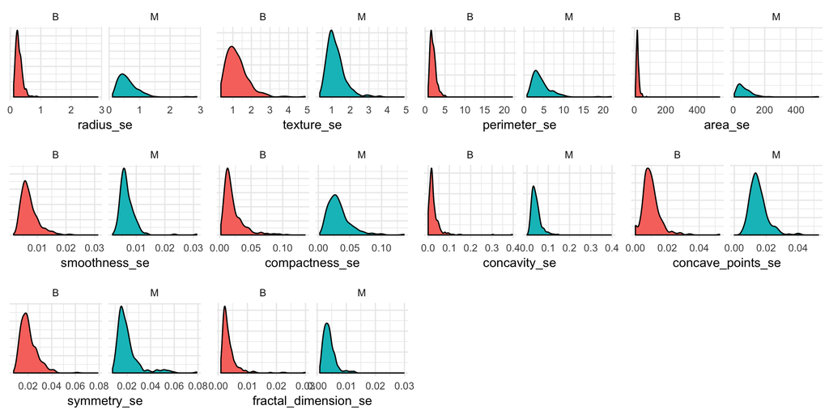

Graphique 2 : répartition des erreurs standard pour chaque variable

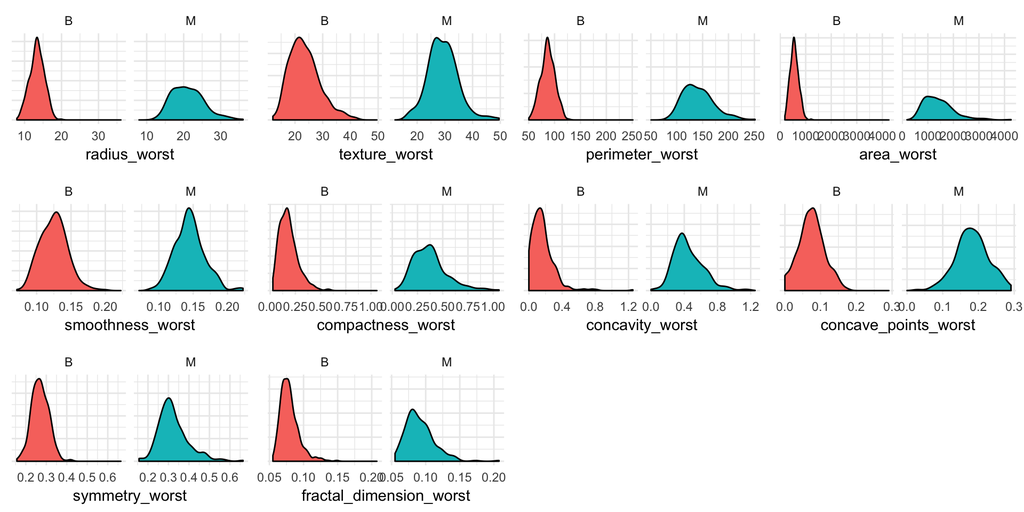

Graphique 3 : répartition des pires valeurs pour chaque variable